# Sample Size Estimation while Controlling Covariates Using the R Package icensmis

Yibai Zhao

October 13, 2015

## Introduction

While gold standard diagnostic test exist for several conditions, in many large-scale epidemiological studies such as the Women’s Health Initiative(WHI), cost considerations dictate that disease status ascertainment be based on self-reports. Self reported outcomes of prevalent and incident disease have been found to be less than perfect. Xiangdong Gu and Raji Balasubramanian develop a method for sample size and power calculation while controlling covariates. In this paper, we introduce a data visualization application based on R Package icensmis and Shiny.

## Functions

The package icensmis has five functions. In this paper, we would introduce one. The function and its description is listed below.

```
icpower(HR, sensitivity, specificity, survivals, N = NULL, power = NULL,  rho = 0.5, alpha = 0.05, pmiss = 0, pcensor = 0, design = "MCAR", negpred = 1)
```

`icpower()` calculates the power and sample in the presence of error-prone diagnostic tests and self-reported outcomes. The function requires the following arguments:

- HR: hazard ratio under the alternative hypothesis
- sensitivity: the sensitivity of test
- specificity: the specificity of test
- survivals: a vector of values of the survival function at each test time for baseline(reference) group
- N or power: if N is specified then power is calculated, if power is specified then sample size is calculated.

There are several optional arguments. **rho** is used to specify the proportion of subjects in base- line(reference) group, the default value is 0.5. alpha is used to specify the type I error, the default is 0.05. **pmiss** is used to specify the vector of the probabilities of each test being randomly missing at each test time, the default is 0. **pcensor** is used to specifiy the vector of the probability of censoring at each visit, assuming censoring process is independent on other missing mechanisms, the default is 0. **design** is used to specify the missing mechanism, either MCAR or NTFP, the default is MCAR. **negpred** is used to specify the negative predictive value at baseline, the default is 1. For more details, please refer to the package manual https://cran.r-project.org/web/packages/icensmis/icensmis.pdf.

## Examples

All data analysis in this section can be available in a Shiny application at http://icensmis.info/shiny/.

### 1 Setup

#### 1.1 Install package

The R package **icensmis** can be downloaded from CRAN.

```
install.packages("icensmis")
```

#### 1.2 Load package

```r
library(icensmis)
```

### 2 Sample Size calculations

#### 2.1 Sample Size as function of Power

```r
library(ggplot2)
## Sensitivity and Specificity
group <- 1:4
parms <- as.data.frame(matrix(c(1, 1, 0.75, 1, 1, 0.75, 0.55, 0.99), ncol = 2, byrow = T))
legtex <- apply(format(parms, nsmall = 2), 1, function(x)paste("(", paste(x, collapse = ", "), ")", sep = "", collpase = ""))
# Sample Size and power
pow1 <- seq(0.1, 0.9, by = 0.1)
pw_gp <- expand.grid(pow1, group)
na <- rep(NA, nrow(pw_gp))
data1 <- cbind(pw_gp, na, na)
data1[data1[,2] == 1,c(3,4)] <- parms[1,]
data1[data1[,2] == 2,c(3,4)] <- parms[2,]
data1[data1[,2] == 3,c(3,4)] <- parms[3,]
data1[data1[,2] == 4,c(3,4)] <- parms[4,]
surv <- exp(log(0.9) * (1:8)/8)
ssize1 <- function(x, y, z) {
  res <- icpower(HR = 2, sensitivity = y, specificity = z, survivals = surv,
                           power = x, rho = 0.5, alpha = 0.05,
                           pmiss = 0, pcensor = 0, design = "MCAR", negpred = 1)
  ss <- res$result[[1]]
  return(ss)
  }
n1 <- mapply(x=data1[,1], y=data1[,3], z=data1[,4], ssize1)
```

[output not shown]

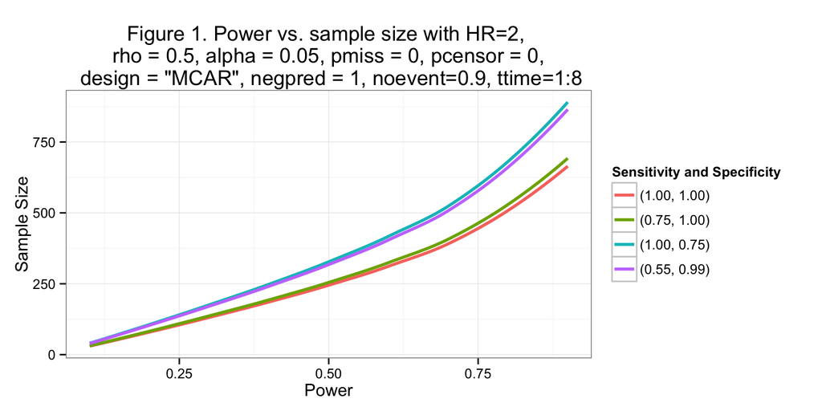

```r
data1 <- cbind(data1, n1)
colnames(data1) <- c("pw", "gp", "sen", "spe", "n")
title1 <- 'Figure 1. Power vs. sample size with HR=2, \n rho = 0.5, alpha = 0.05, pmiss = 0, pcensor = 0, \n design = "MCAR", negpred = 1, noevent=0.9, ttime=1:8'
g <- ggplot(aes(x = pw, y = n, group=factor(gp)), data = data1)
g + geom_smooth(se = F, aes(colour = factor(data1$gp)), size=1)+
  ylab("Sample Size")+ xlab("Power")+ labs(title = title1)+
  scale_colour_discrete(name="Sensitivity and Specificity",
                       breaks=c("1", "2", "3", "4"),
                       labels=legtex)+ theme_bw()
```

From **Figure 1**, we see power has a positive relationship with sample size, that is the stronger power we need, the more sample size. For one power, higher sensitivity or specificity results in less sample size demand. More sample size is needed, when we have a perfect sensitivity but a poor specificity than a perfect specificity but a poor sensitivity.

#### 2.2 Sample Size as function of Hazard Ratio

```r
group <- 1:4
HR <- seq(1.25, 2.5, by = 0.05)
hr_gp <- expand.grid(HR, group)
na <- rep(NA, nrow(hr_gp))
data2 <- cbind(hr_gp, na, na)
data2[data2[,2] == 1,c(3,4)] <- parms[1,]
data2[data2[,2] == 2,c(3,4)] <- parms[2,]
data2[data2[,2] == 3,c(3,4)] <- parms[3,]
data2[data2[,2] == 4,c(3,4)] <- parms[4,]
surv <- exp(log(0.9) * (1:8)/8)
ssize2 <- function(x, y, z) {
  res <- icpower(HR = x, sensitivity = y, specificity = z, survivals = surv,
                 power = 0.9, rho = 0.5, alpha = 0.05,
                 pmiss = 0, pcensor = 0, design = "MCAR", negpred = 1)
  ss <- res$result[[1]]
  return(ss)
}
n2 <- mapply(x=data2[,1], y=data2[,3], z=data2[,4], ssize2)
```

[output not shown]

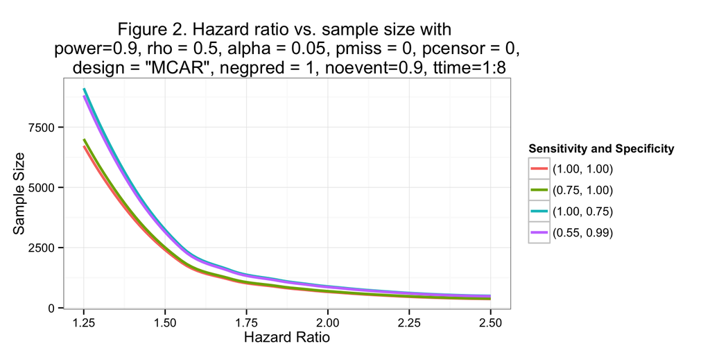

```r
data2 <- cbind(data2, n2)
colnames(data2) <- c("hr", "gp", "sen", "spe", "n")
title2 <- 'Figure 2. Hazard ratio vs. sample size with \n power=0.9, rho = 0.5, alpha = 0.05, pmiss = 0, pcensor = 0, \n design = "MCAR", negpred = 1, noevent=0.9, ttime=1:8'
g <- ggplot(aes(x = hr, y = n, group=factor(gp)), data = data2)
g + geom_smooth(se = F, aes(colour = factor(data2$gp)), size=1)+
  ylab("Sample Size")+ xlab("Hazard Ratio")+ labs(title=title2)+
  scale_colour_discrete(name="Sensitivity and Specificity",
                        breaks=c("1", "2", "3", "4"),
                        labels=legtex)+ theme_bw()
```

From **Figure 2**, we see that when harzard ratio increase we need less sample size to maintain a strong power. For one hazard ratio, higher sensitivity or specificity results in less sample size demand. More sample size is needed, when we have a perfect sensitivity but a poor specificity than a perfect specificity but a poor sensitivity. The lines will converge to one point when hazard ratio is large enough.

#### 2.3 Sample size as function of cumulative incidence

```r
ci <- seq(0.05, 0.95, by = 0.05)
ci_gp <- expand.grid(ci, group)
na <- rep(NA, nrow(ci_gp))
data3 <- cbind(ci_gp, na, na)
data3[data3[,2] == 1,c(3,4)] <- parms[1,]
data3[data3[,2] == 2,c(3,4)] <- parms[2,]
data3[data3[,2] == 3,c(3,4)] <- parms[3,]
data3[data3[,2] == 4,c(3,4)] <- parms[4,]
ssize3 <- function(x, y, z) {
  testtimes <- c(2, 4, 6, 8)
  res <- icpower(HR = 1.25, sensitivity = y, specificity = z,
                 survivals = exp(log(1-x) * testtimes/max(testtimes)),
                 power = 0.9, rho = 0.5, alpha = 0.05,
                 pmiss = 0, pcensor = 0, design = "MCAR", negpred = 1)
  ss <- res$result[[1]]
  return(ss)
}
n3 <- mapply(x=data3[,1], y=data3[,3], z=data3[,4], ssize3)
```

[output not shown]

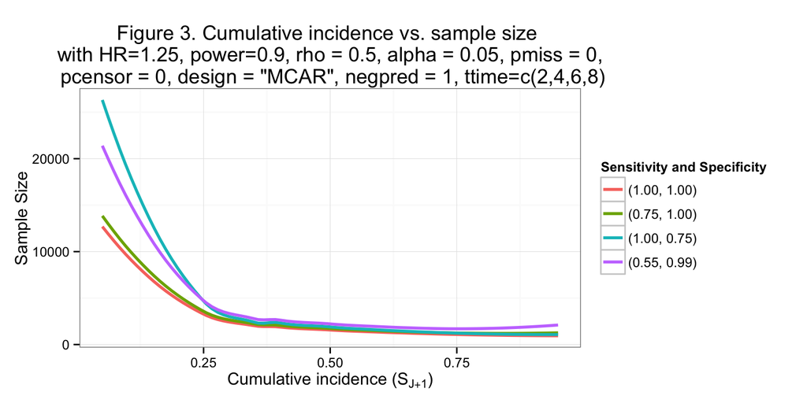

```r
data3 <- cbind(data3, n3)
colnames(data3) <- c("ci", "gp", "sen", "spe", "n")
title3 <- 'Figure 3. Cumulative incidence vs. sample size \n with HR=1.25, power=0.9, rho = 0.5, alpha = 0.05, pmiss = 0, \n pcensor = 0, design = "MCAR", negpred = 1, ttime=c(2,4,6,8)'
g <- ggplot(aes(x = ci, y = n, group=factor(gp)), data = data3)
g + geom_smooth(se = F, aes(colour = factor(data3$gp)), size=1)+
  ylab("Sample Size")+ xlab(expression(paste("Cumulative incidence (", S[J + 1], ")")))+ labs(title=title3)+
  scale_colour_discrete(name="Sensitivity and Specificity",
                        breaks=c("1", "2", "3", "4"),
                        labels=legtex)+ theme_bw()
```

From **Figure 3**, we see that when cumulative incidence increase we need less sample size to maintain a strong power. As the incidence increasing, sensitivity and specificity have little effect on the sample size.

#### 2.4 Sample size as function of number of tests

```r
ntest <- 2:10
nt_gp <- expand.grid(ntest, group)
na <- rep(NA, nrow(nt_gp))
data4 <- cbind(nt_gp, na, na)
data4[data4[,2] == 1,c(3,4)] <- parms[1,]
data4[data4[,2] == 2,c(3,4)] <- parms[2,]
data4[data4[,2] == 3,c(3,4)] <- parms[3,]
data4[data4[,2] == 4,c(3,4)] <- parms[4,]
ssize4 <- function(x, y, z) {
  testtimes <- 1:x
  res <- icpower(HR = 1.25, sensitivity = y, specificity = z,
                 survivals = exp(log(1-0.1) * testtimes/max(testtimes)),
                 power = 0.9, rho = 0.5, alpha = 0.05,
                 pmiss = 0, pcensor = 0, design = "MCAR", negpred = 1)
  ss <- res$result[[1]]
  return(ss)
}
n4 <- mapply(x=data4[,1], y=data4[,3], z=data4[,4], ssize4)
```

[output not shown]

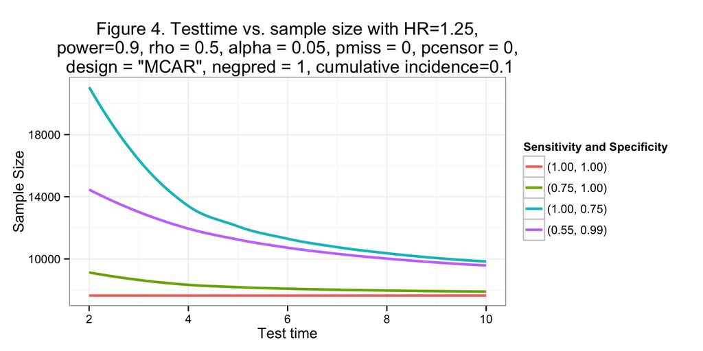

```r
data4 <- cbind(data4, n4)
colnames(data4) <- c("ttime", "gp", "sen", "spe", "n")
title4 <- 'Figure 4. Testtime vs. sample size with HR=1.25,\n power=0.9, rho = 0.5, alpha = 0.05, pmiss = 0, pcensor = 0, \n design = "MCAR", negpred = 1, cumulative incidence=0.1'
g <- ggplot(aes(x = ttime, y = n, group=factor(gp)), data = data4)
g + geom_smooth(se = F, aes(colour = factor(data4$gp)), size=1)+
  ylab("Sample Size")+ xlab("Test time")+ labs(title=title4)+
  scale_colour_discrete(name="Sensitivity and Specificity",
                        breaks=c("1", "2", "3", "4"),
                        labels=legtex)+ theme_bw()
```